# Positron source with cooling

The task is to look at posible way of ionization cooling for positron beam. We've got submillimeter electron beam falling on the tungsten target. Electromagnetic shower produces for us electrons and positrons. Radius of the target is 3 cm.

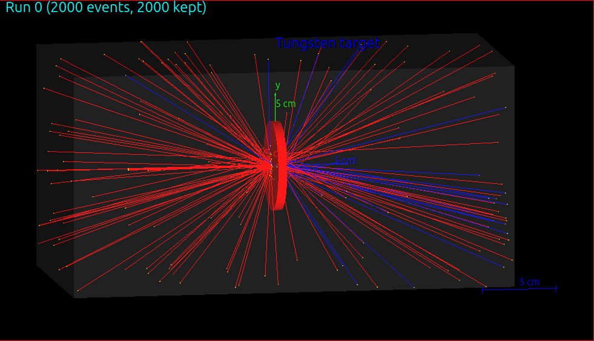

As it can be seen electrons and positrons produced are spread everywhere. The next step is to add magnetic field and to gather the positrons. We whant to set the magnetic mirror to catch the positrons inside trap.

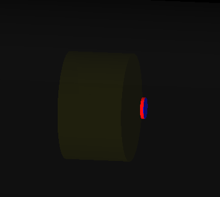

The coil right before the target with magnetic field 5 Tesla is the first magnetic plug. The length is 6 cm, radius is 5 cm.

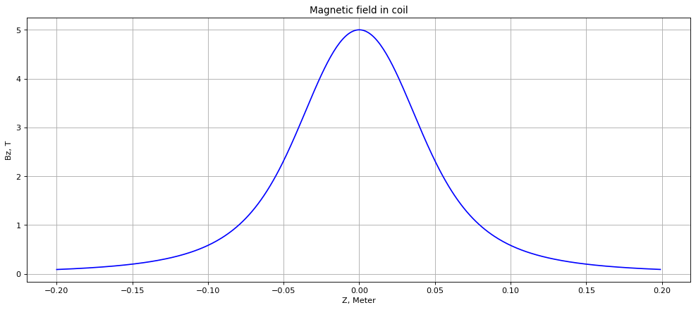

```python
from array import array
import numpy as np
import pylab as pl
import matplotlib.pyplot as plt
from matplotlib.pyplot import figure
import math

# Constant
mu0 = math.pi
# Solenoid
B0 = 5 # Tesla
L = 0.06 # Meter
R = 0.05 # Meter
NI = B0*L/mu0/(L/2/math.sqrt((L/2)*(L/2)+R*R))

z = array('d',[])
Bz = array('d',[])

for x in np.arange(-0.2, 0.2, 0.001):
    z.append(x)
    Bx = mu0*NI/(2*L)*((x+L/2)/math.sqrt((x+L/2)*(x+L/2)+R*R)-((x-L/2)/math.sqrt((x-L/2)*(x-L/2)+R*R)))
    Bz.append(Bx)

figure(figsize=(15, 6), dpi=81)
plt.plot(z, Bz, "b")
plt.title('Magnetic field in coil')
plt.ylabel('Bz, T')
plt.xlabel('Z, Meter')
plt.grid(True)
plt.show()
```

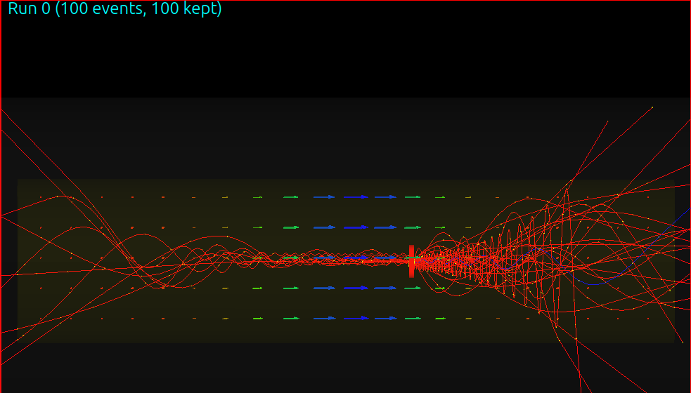

In this system the amount of electrons and positrons against thickness of tungsten target is represented on next picture. Taken in account are particles escaped the target in front direction. On this picture we see area of magnetic field with target and electrons/positrons affected by this field. Length of the arrows represents the strength of magnetic field. And on the picture above the amplitude of the magnetic field in the area near target.

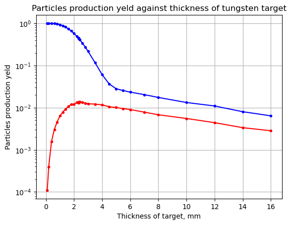

```python
from array import array
import numpy as np
import pylab as pl
import matplotlib.pyplot as plt
from matplotlib.pyplot import figure
import math

N = 100000 # Number of events
# Lenght of the target, mm
L = array('d',[0.1,0.2,0.4,0.6,0.8,1,1.2,1.4,1.6,1.8,2,2.2,2.3,2.33,2.35,2.4,2.6,2.8,3,3.5,4,4.5,5,5.5,6,7,8,10,12,14,16])
# Number of e+ & e+ born during the run
Noe = array('i',[100595,100907,100779,99499,97190,93484,88494,82222,74737,66575,57988,49731,45583,44375,43517,41648,34325,27588,21880,11685,6110,3680,2820,2548,2346,2044,1752,1329,1099,804,642])
Nop = array('i',[11,39,155,305,457,638,787,929,1067,1206,1215,1336,1302,1318,1365,1381,1344,1287,1240,1217,1169,1054,1010,953,905,785,680,555,442,336,284])

ey = np.divide(Noe,N)
py = np.divide(Nop,N)

#figure(figsize=(15, 6), dpi=81)
plt.plot(L, ey, "b.", L, ey, "b", L, py, "r.", L, py, "r")
plt.title('Particles production yeld against thickness of tungsten target')
plt.ylabel('Particles production yeld')
plt.xlabel('Thickness of target, mm')
plt.yscale('log')
plt.grid(True)
plt.show()
```

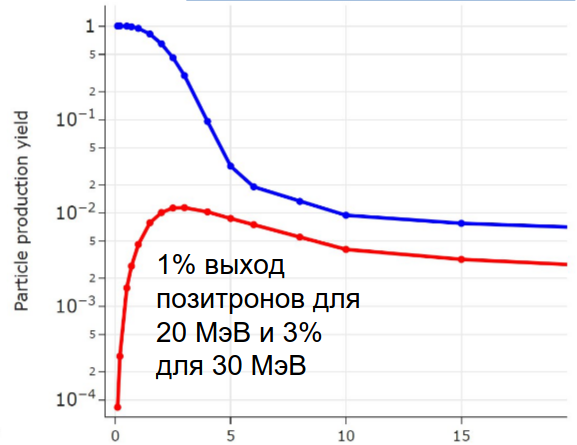

Also we can look on the energy deposited in the target through electromagnetic showeragainst it's thickness

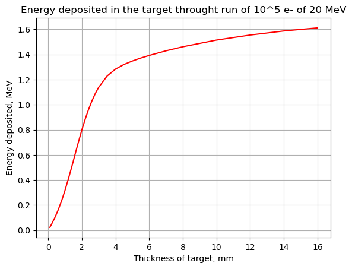

```python
from array import array
import numpy as np
import pylab as pl
import matplotlib.pyplot as plt
from matplotlib.pyplot import figure
import math

N = 100000 # Number of events
# Lenght of the target, mm
L = array('d',[0.1,0.2,0.4,0.6,0.8,1,1.2,1.4,1.6,1.8,2,2.2,2.3,2.33,2.35,2.4,2.6,2.8,3,3.5,4,4.5,5,5.5,6,7,8,10,12,14,16])
# Energy deposited GeV
E = array('d',[22.8207,47.1157,101.002,163.037,234.699,317.108,408.129,503.606,604.473,703.433,797.934,884.022,923.659,935.371,942.812,961.56,1029.95,1088.77,1137.9,1228.02,1283.4,1320.02,1347.71,1371.41,1392.13,1428.95,1461.26,1514.59,1554.83,1587.13,1611.68])
EG = np.divide(E,1000)

#figure(figsize=(15, 6), dpi=81)
plt.plot(L, EG, "r")
plt.title('Energy deposited in the target throught run of 10^5 e- of 20 MeV')
plt.ylabel('Energy deposited, MeV')
plt.xlabel('Thickness of target, mm')
#plt.yscale('log')
plt.grid(True)
plt.show()
```

The next step is to make full magnetic trap for positnons produced on target. The lenght of magnetic trap is 2 meters with two 5 Tesla magnetic plugs on each side and 0.5 Tesla magnetic field in the center.

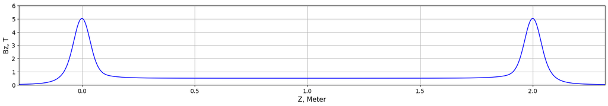

```python
from array import array
import numpy as np
import pylab as pl
import matplotlib.pyplot as plt
from matplotlib.pyplot import figure
import math

# Constant
mu0 = math.pi
# Solenoids on the ends
B0 = 5 # Tesla
L = 0.06 # Meter
R = 0.05 # Meter
NI = B0*L/mu0/(L/2/math.sqrt((L/2)*(L/2)+R*R))
# Solenoid in the mid
B0m = 0.5 # Tesla
Lm = 1.8 # Meter
Rm = 0.05 # Meter
NIm = B0m*Lm/mu0/(Lm/2/math.sqrt((Lm/2)*(Lm/2)+Rm*Rm))

z = array('d',[])
Bz = array('d',[])

for x in np.arange(-0.5, 2.5, 0.001):
    z.append(x)
    Bl = mu0*NI/(2*L)*((x+L/2)/math.sqrt((x+L/2)*(x+L/2)+R*R)-((x-L/2)/math.sqrt((x-L/2)*(x-L/2)+R*R)))
    Br = mu0*NI/(2*L)*((x-2+L/2)/math.sqrt((x-2+L/2)*(x-2+L/2)+R*R)-((x-2-L/2)/math.sqrt((x-2-L/2)*(x-2-L/2)+R*R)))
    Bm = mu0*NIm/(2*Lm)*((x-1+Lm/2)/math.sqrt((x-1+Lm/2)*(x-1+Lm/2)+Rm*Rm)-((x-1-Lm/2)/math.sqrt((x-1-Lm/2)*(x-1-Lm/2)+Rm*Rm)))
    Bz.append(Bl+Br+Bm)

figure(figsize=(22, 3), dpi=80)
plt.plot(z, Bz, "b")
#plt.title('Magnetic field')
plt.ylabel('Bz, T', fontsize=14)
plt.xlabel('Z, Meter', fontsize=14)
plt.xticks(fontsize=12)
plt.yticks(fontsize=12)
plt.grid(True)
plt.axis([-0.28, 2.32, 0, 6])
plt.show()
```

[figure not shown]

For this moment only a longitudial component of magnetic field was added. And this is not enough for magnetic mirror works properly. So the next step is to make magnetic field full and check it works.

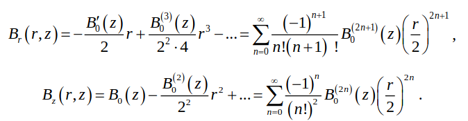

```python
    From paraxial decomposition we take first terms
```

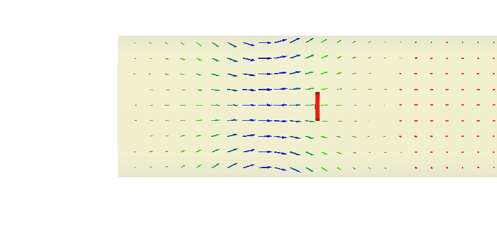

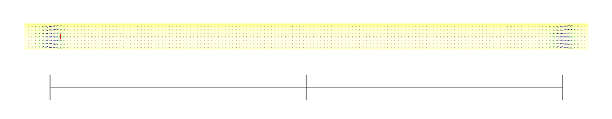

Now we have got some to moments to adjust. Positrons leave the tube because of: 1. Electric field accelerating positrons - electric field stay for 5 ns now 2. Positrons escape tube during passing the air segment lets make tube wider from 5 cm to 7 cm 3. Positrons falling on the target - move target in magnetic field of a plug

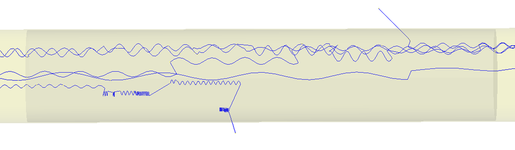

Most of the particles continue to leave the tube. It seems we need gas with higher density. Some times we get positron stoped in the gas

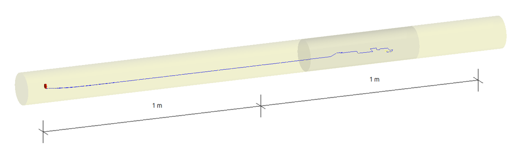

Have added second terms for paraxial decomposition

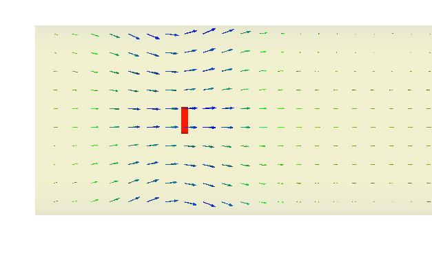

Now let's look at phase pictures and momentum distribution of positrons quited the target

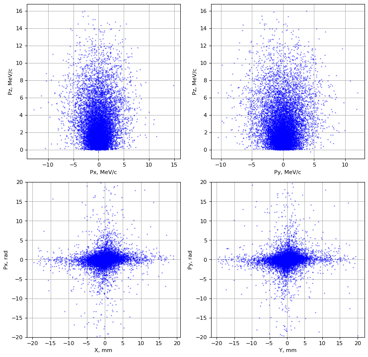

```python
from array import array
import numpy as np
import pylab as pl
import matplotlib.pyplot as plt
from matplotlib.pyplot import figure
import math

# Coordinates,mm and momenta,MeV for Z after target
with open('R_AT_Xcoord.txt', 'r') as file:
    X = [float(x) for x in file.read().split(',')]
with open('R_AT_Ycoord.txt', 'r') as file:
    Y = [float(x) for x in file.read().split(',')]
with open('R_AT_Xmom.txt', 'r') as file:
    Px = [float(x) for x in file.read().split(',')]
with open('R_AT_Ymom.txt', 'r') as file:
    Py = [float(x) for x in file.read().split(',')]
with open('R_AT_Zmom.txt', 'r') as file:
    Pz = [float(x) for x in file.read().split(',')]

X1 = [a / b for a, b in zip(Px, Pz)]
Y1 = [a / b for a, b in zip(Py, Pz)]

figure(figsize=(10, 10), dpi=80)

plt.subplot(221)
plt.plot(Px, Pz, 'o', markersize=1, color='blue', alpha=0.5)
plt.ylabel('Pz, MeV/c')
plt.xlabel('Px, MeV/c')
plt.grid(True)

plt.subplot(222)
plt.plot(Py, Pz, 'o', markersize=1, color='blue', alpha=0.5)
plt.ylabel('Pz, MeV/c')
plt.xlabel('Py, MeV/c')
plt.grid(True)

plt.subplot(223)
plt.plot(X, X1, 'o', markersize=1, color='blue', alpha=0.5)
plt.ylabel('Px, rad')
plt.xlabel('X, mm')
plt.ylim(-20,20)
plt.grid(True)

plt.subplot(224)
plt.plot(Y, Y1, 'o', markersize=1, color='blue', alpha=0.5)
plt.ylabel('Py, rad')
plt.xlabel('Y, mm')
plt.ylim(-20,20)
plt.grid(True)

plt.subplots_adjust(top=0.92, bottom=0.08, left=0.10, right=0.95, hspace=0.15, wspace=0.2)

plt.show()
```

There are phase pictures and momentum distribution of positrons right after the target. In this calculation ~10^6 electrons were falling on the target. About ~12000 positrons were born. And the calculation have taken about ~22 hours

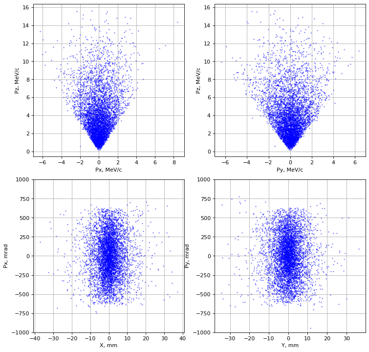

```python
from array import array
import numpy as np
import pylab as pl
import matplotlib.pyplot as plt
from matplotlib.pyplot import figure
import math

# Coordinates,mm and momenta,MeV for Z after target
with open('R_C_Xcoord.txt', 'r') as file:
    X = [float(x) for x in file.read().split(',')]
with open('R_C_Ycoord.txt', 'r') as file:
    Y = [float(x) for x in file.read().split(',')]
with open('R_C_Xmom.txt', 'r') as file:
    Px = [float(x) for x in file.read().split(',')]
with open('R_C_Ymom.txt', 'r') as file:
    Py = [float(x) for x in file.read().split(',')]
with open('R_C_Zmom.txt', 'r') as file:
    Pz = [float(x) for x in file.read().split(',')]

X1 = [a / b *1000 for a, b in zip(Px, Pz)]
Y1 = [a / b *1000 for a, b in zip(Py, Pz)]

figure(figsize=(10, 10), dpi=80)

plt.subplot(221)
plt.plot(Px, Pz, 'o', markersize=1, color='blue', alpha=0.5)
plt.ylabel('Pz, MeV/c')
plt.xlabel('Px, MeV/c')
plt.grid(True)

plt.subplot(222)
plt.plot(Py, Pz, 'o', markersize=1, color='blue', alpha=0.5)
plt.ylabel('Pz, MeV/c')
plt.xlabel('Py, MeV/c')
plt.grid(True)

plt.subplot(223)
plt.plot(X, X1, 'o', markersize=1, color='blue', alpha=0.5)
plt.ylabel('Px, mrad')
plt.xlabel('X, mm')
plt.ylim(-1000,1000)
plt.grid(True)

plt.subplot(224)
plt.plot(Y, Y1, 'o', markersize=1, color='blue', alpha=0.5)
plt.ylabel('Py, mrad')
plt.xlabel('Y, mm')
plt.ylim(-1000,1000)
plt.grid(True)

plt.subplots_adjust(top=0.92, bottom=0.08, left=0.10, right=0.95, hspace=0.15, wspace=0.2)

plt.show()
```

There are phase pictures and momentum distribution of positrons in the center of the trap. In this calculation 0.5*10^6 electrons were falling on the target. About ~5400 positrons passed the center.

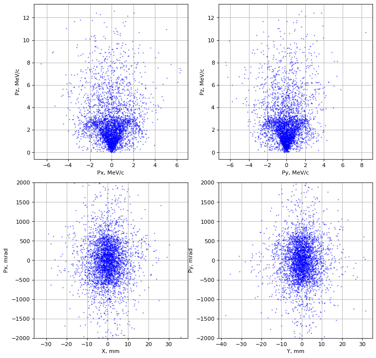

```python
from array import array
import numpy as np
import pylab as pl
import matplotlib.pyplot as plt
from matplotlib.pyplot import figure
import math

# Coordinates,mm and momenta,MeV for Z after target
with open('R_3M_Xcoord.txt', 'r') as file:
    X = [float(x) for x in file.read().split(',')]
with open('R_3M_Ycoord.txt', 'r') as file:
    Y = [float(x) for x in file.read().split(',')]
with open('R_3M_Xmom.txt', 'r') as file:
    Px = [float(x) for x in file.read().split(',')]
with open('R_3M_Ymom.txt', 'r') as file:
    Py = [float(x) for x in file.read().split(',')]
with open('R_3M_Zmom.txt', 'r') as file:
    Pz = [float(x) for x in file.read().split(',')]

X1 = [a / b *1000 for a, b in zip(Px, Pz)]
Y1 = [a / b *1000 for a, b in zip(Py, Pz)]

figure(figsize=(10, 10), dpi=80)

plt.subplot(221)
plt.plot(Px, Pz, 'o', markersize=1, color='blue', alpha=0.5)
plt.ylabel('Pz, MeV/c')
plt.xlabel('Px, MeV/c')
plt.grid(True)

plt.subplot(222)
plt.plot(Py, Pz, 'o', markersize=1, color='blue', alpha=0.5)
plt.ylabel('Pz, MeV/c')
plt.xlabel('Py, MeV/c')
plt.grid(True)

plt.subplot(223)
plt.plot(X, X1, 'o', markersize=1, color='blue', alpha=0.5)
plt.ylabel('Px, mrad')
plt.xlabel('X, mm')
plt.ylim(-2000,2000)
plt.grid(True)

plt.subplot(224)
plt.plot(Y, Y1, 'o', markersize=1, color='blue', alpha=0.5)
plt.ylabel('Py, mrad')
plt.xlabel('Y, mm')
plt.ylim(-2000,2000)
plt.grid(True)

plt.subplots_adjust(top=0.92, bottom=0.08, left=0.10, right=0.95, hspace=0.15, wspace=0.2)

plt.show()
```

There are phase pictures and momentum distribution of positrons in the center of the trap after electric field 3 MeV deaccelerating the positron beam. In this calculation 0.5*10^6 electrons were falling on the target. About ~3700 positrons passed the center.

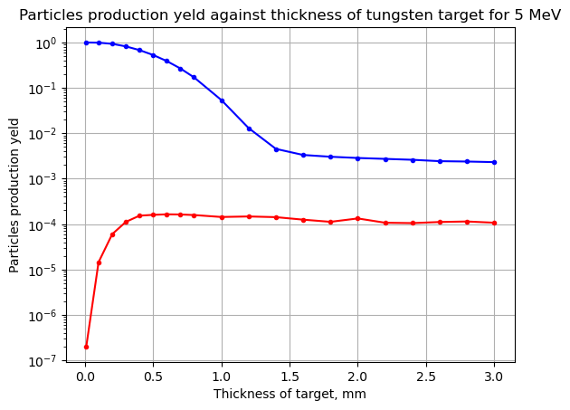

```python
from array import array
import numpy as np
import pylab as pl
import matplotlib.pyplot as plt
from matplotlib.pyplot import figure
import math

N = 10000000 # Number of events
# Lenght of the target, mm
L = array('d',[0.01,0.1,0.2,0.3,0.4,0.5,0.6,0.7,0.8,1,1.2,1.4,1.6,1.8,2,2.2,2.4,2.6,2.8,3])
# Number of e+ & e+ born during the run
Noe = array('i',[10005600, 9909200, 9338730, 8204540, 6794350, 5304600, 3897180, 2674440, 1703860, 539825, 130070, 45280, 33260, 30400, 28550, 27280, 26060, 24290, 23850, 23140])
Nop = array('i',[2, 144, 598, 1117, 1529, 1596, 1639, 1626, 1580, 1432, 1470, 1420, 1250, 1120, 1330, 1070, 1050, 1110, 1140, 1070])

ey = np.divide(Noe,N)
py = np.divide(Nop,N)

#figure(figsize=(15, 6), dpi=81)
plt.plot(L, ey, "b.", L, ey, "b", L, py, "r.", L, py, "r")
plt.title('Particles production yeld against thickness of tungsten target for 5 MeV')
plt.ylabel('Particles production yeld')
plt.xlabel('Thickness of target, mm')
plt.yscale('log')
plt.grid(True)
plt.show()
```

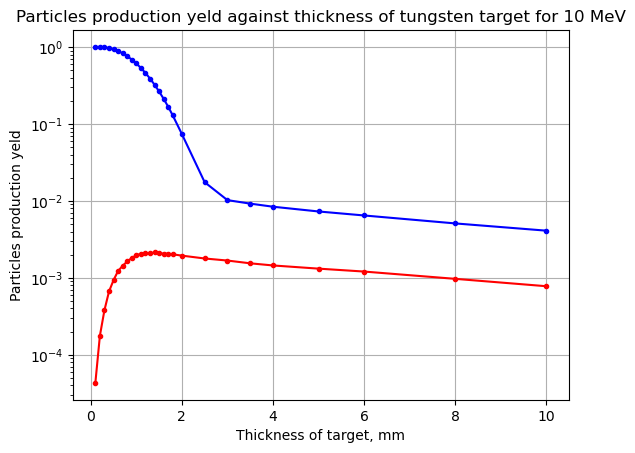

```python
from array import array
import numpy as np
import pylab as pl
import matplotlib.pyplot as plt
from matplotlib.pyplot import figure
import math

N = 2000000 # Number of events
# Lenght of the target, mm
L = array('d',[0.1,0.2,0.3,0.4,0.5,0.6,0.7,0.8,0.9,1,1.1,1.2,1.3,1.4,1.5,1.6,1.7,1.8,2,2.5,3,3.5,4,5,6,8,10])
# Number of e+ & e+ born during the run
Noe = array('i',[2012890, 2015830, 1993370, 1953660, 1884030, 1786520, 1667100, 1529240, 1380810, 1227130, 1073840, 924503, 782729, 649674, 530817, 425820, 335659, 258997, 148310, 35068, 20507, 18468, 16835, 14600, 12954, 10210, 8218])
Nop = array('i',[86, 354, 761, 1329, 1872, 2461, 2870, 3268, 3628, 3939, 4112, 4186, 4158, 4286, 4227, 4114, 4126, 4046, 3891, 3572, 3358, 3091, 2899, 2636, 2415, 1942, 1557])

ey = np.divide(Noe,N)
py = np.divide(Nop,N)

#figure(figsize=(15, 6), dpi=81)
plt.plot(L, ey, "b.", L, ey, "b", L, py, "r.", L, py, "r")
plt.title('Particles production yeld against thickness of tungsten target for 10 MeV')
plt.ylabel('Particles production yeld')
plt.xlabel('Thickness of target, mm')
plt.yscale('log')
plt.grid(True)
plt.show()
```

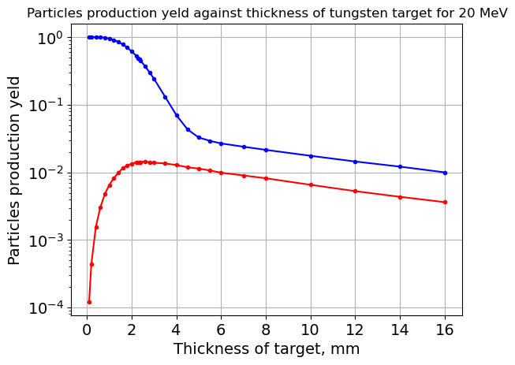

```python
from array import array
import numpy as np
import pylab as pl
import matplotlib.pyplot as plt
from matplotlib.pyplot import figure
import math

N = 1000000 # Number of events
# Lenght of the target, mm
L = array('d',[0.1,0.2,0.4,0.6,0.8,1,1.2,1.4,1.6,1.8,2,2.2,2.3,2.35,2.4,2.6,2.8,3,3.5,4,4.5,5,5.5,6,7,8,10,12,14,16])
# Number of e+ & e+ born during the run
Noe = array('i',[1006820, 1011750, 1015160, 1009750, 993299, 961795, 919587, 860930, 789478, 708503, 622690, 537343, 494110, 473368, 453059, 375767, 304796, 243995, 131899, 70725, 43396, 32967, 29372, 26903, 24060, 21592, 17653, 14520, 12189, 10033])
Nop = array('i',[121, 440, 1549, 3018, 4747, 6521, 8212, 9819, 11576, 12698, 13478, 14114, 14229, 14251, 14263, 14532, 14109, 13933, 13579, 12879, 11939, 11408, 10705, 9917, 9023, 8199, 6561, 5283, 4354, 3630])

ey = np.divide(Noe,N)
py = np.divide(Nop,N)

#figure(figsize=(15, 6), dpi=81)
plt.plot(L, ey, "b.", L, ey, "b", L, py, "r.", L, py, "r")
plt.title('Particles production yeld against thickness of tungsten target for 20 MeV')
plt.ylabel('Particles production yeld', fontsize=14)
plt.xlabel('Thickness of target, mm', fontsize=14)
plt.yscale('log')
plt.grid(True)
plt.xticks(fontsize=14)
plt.yticks(fontsize=14)
plt.show()
```

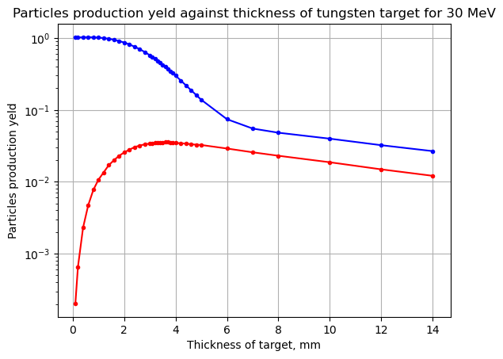

```python
from array import array
import numpy as np
import pylab as pl
import matplotlib.pyplot as plt
from matplotlib.pyplot import figure
import math

N = 1000000 # Number of events
# Lenght of the target, mm
L = array('d',[0.1,0.2,0.4,0.6,0.8,1,1.2,1.4,1.6,1.8,2,2.2,2.4,2.6,2.8,3,3.1,3.2,3.3,3.4,3.5,3.6,3.7,3.8,3.9,4,4.2,4.4,4.6,4.8,5,6,7,8,10,12,14])
# Number of e+ & e+ born during the run
Noe = array('i',[1007270, 1012900, 1019770, 1020710, 1017400, 1008000, 991862, 970171, 940341, 902934, 859533, 809291, 754388, 696157, 634816, 571966, 541537, 511897, 481459, 452275, 424491, 397030, 370405, 345995, 321456, 298497, 255618, 218815, 187645, 160414, 137592, 73923, 54813, 47986, 39649, 32187, 26630])
Nop = array('i',[203, 657, 2305, 4712, 7717, 10690, 13470, 16998, 19879, 22889, 25547, 27832, 30230, 31780, 33107, 33850, 34277, 34522, 34667, 35151, 35279, 35497, 35464, 35078, 34814, 34515, 34232, 33874, 33259, 32669, 32391, 28934, 25640, 22948, 18641, 14856, 12080])

ey = np.divide(Noe,N)
py = np.divide(Nop,N)

#figure(figsize=(15, 6), dpi=81)
plt.plot(L, ey, "b.", L, ey, "b", L, py, "r.", L, py, "r")
plt.title('Particles production yeld against thickness of tungsten target for 30 MeV')
plt.ylabel('Particles production yeld')
plt.xlabel('Thickness of target, mm')
plt.yscale('log')
plt.grid(True)
plt.show()
```

Next step was an adjustment: 1. Electron beam was made Gaussian and 1 cm in diameter 2. Aperture of channel is 15 cm in diameter now 3. Target lay in max of magnetic field now

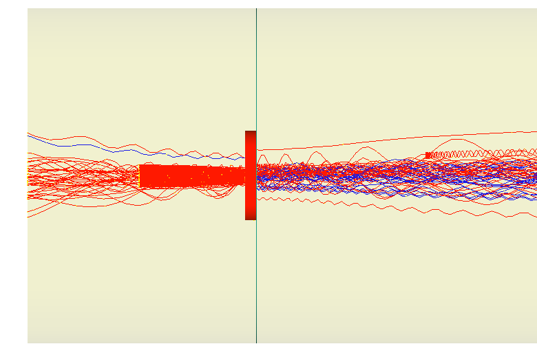

Now we have 4 detector surface: 1. Right after target 2. + 10cm after target to check the change of phase picture in the end of adiabatic device 3. After section with electric field 4. After the magnetic mirror to check how many electrons did escape

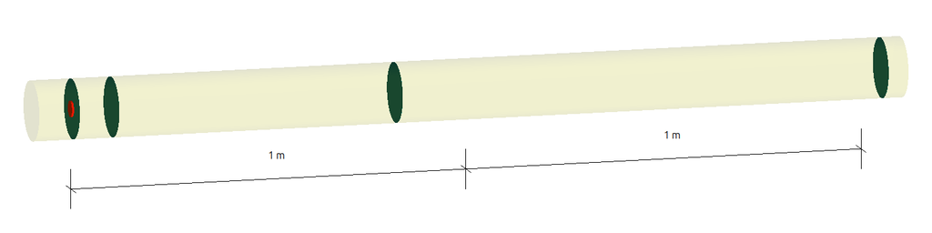

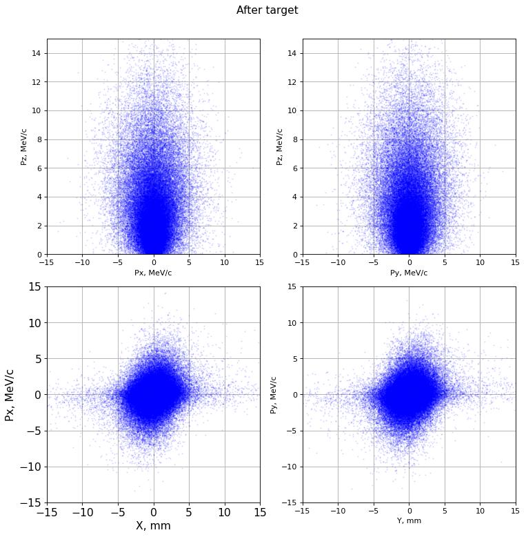

```python
from array import array
import numpy as np
import pylab as pl
import matplotlib.pyplot as plt
from matplotlib.pyplot import figure
import math

# Coordinates,mm and momenta,MeV for Z after target
with open('R_2m_el_wg/R_X_at.txt', 'r') as file:
    X = [float(x) for x in file.read().split(',')]
with open('R_2m_el_wg/R_Y_at.txt', 'r') as file:
    Y = [float(x) for x in file.read().split(',')]
with open('R_2m_el_wg/R_Px_at.txt', 'r') as file:
    Px = [float(x) for x in file.read().split(',')]
with open('R_2m_el_wg/R_Py_at.txt', 'r') as file:
    Py = [float(x) for x in file.read().split(',')]
with open('R_2m_el_wg/R_Pz_at.txt', 'r') as file:
    Pz = [float(x) for x in file.read().split(',')]

# X1 = [a / b for a, b in zip(Px, Pz)]
# Y1 = [a / b for a, b in zip(Py, Pz)]

figure(figsize=(10, 10), dpi=80)

plt.subplot(221)
plt.plot(Px, Pz, 'o', markersize=1, color='blue', alpha=0.1)
plt.ylabel('Pz, MeV/c')
plt.xlabel('Px, MeV/c')
plt.ylim(0,15)
plt.xlim(-15,15)
plt.grid(True)

plt.subplot(222)
plt.plot(Py, Pz, 'o', markersize=1, color='blue', alpha=0.1)
plt.ylabel('Pz, MeV/c')
plt.xlabel('Py, MeV/c')
plt.ylim(0,15)
plt.xlim(-15,15)
plt.grid(True)

plt.subplot(223)
plt.plot(X, Px, 'o', markersize=1, color='blue', alpha=0.1)
plt.ylabel('Px, MeV/c',fontsize=14)
plt.xlabel('X, mm',fontsize=14)
plt.ylim(-15,15)
plt.xlim(-15,15)
plt.xticks(fontsize=14)
plt.yticks(fontsize=14)
plt.grid(True)

plt.subplot(224)
plt.plot(Y, Py, 'o', markersize=1, color='blue', alpha=0.1)
plt.ylabel('Py, MeV/c')
plt.xlabel('Y, mm')
plt.ylim(-15,15)
plt.xlim(-15,15)
plt.grid(True)

plt.suptitle("After target", fontsize=14)

plt.subplots_adjust(top=0.92, bottom=0.08, left=0.10, right=0.95, hspace=0.15, wspace=0.2)

plt.show()
```

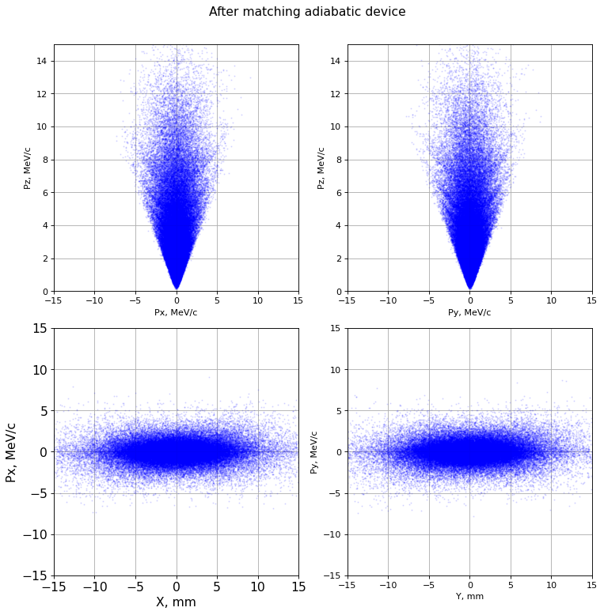

```python
from array import array
import numpy as np
import pylab as pl
import matplotlib.pyplot as plt
from matplotlib.pyplot import figure
import math

# Coordinates,mm and momenta,MeV for Z after target
with open('R_2m_el_wg/R_X_ad.txt', 'r') as file:
    X = [float(x) for x in file.read().split(',')]
with open('R_2m_el_wg/R_Y_ad.txt', 'r') as file:
    Y = [float(x) for x in file.read().split(',')]
with open('R_2m_el_wg/R_Px_ad.txt', 'r') as file:
    Px = [float(x) for x in file.read().split(',')]
with open('R_2m_el_wg/R_Py_ad.txt', 'r') as file:
    Py = [float(x) for x in file.read().split(',')]
with open('R_2m_el_wg/R_Pz_ad.txt', 'r') as file:
    Pz = [float(x) for x in file.read().split(',')]

# X1 = [a / b for a, b in zip(Px, Pz)]
# Y1 = [a / b for a, b in zip(Py, Pz)]

figure(figsize=(10, 10), dpi=80)

plt.subplot(221)
plt.plot(Px, Pz, 'o', markersize=1, color='blue', alpha=0.1)
plt.ylabel('Pz, MeV/c')
plt.xlabel('Px, MeV/c')
plt.ylim(0,15)
plt.xlim(-15,15)
plt.grid(True)

plt.subplot(222)
plt.plot(Py, Pz, 'o', markersize=1, color='blue', alpha=0.1)
plt.ylabel('Pz, MeV/c')
plt.xlabel('Py, MeV/c')
plt.ylim(0,15)
plt.xlim(-15,15)
plt.grid(True)

plt.subplot(223)
plt.plot(X, Px, 'o', markersize=1, color='blue', alpha=0.1)
plt.ylabel('Px, MeV/c',fontsize=14)
plt.xlabel('X, mm',fontsize=14)
plt.ylim(-15,15)
plt.xlim(-15,15)
plt.xticks(fontsize=14)
plt.yticks(fontsize=14)
plt.grid(True)

plt.subplot(224)
plt.plot(Y, Py, 'o', markersize=1, color='blue', alpha=0.1)
plt.ylabel('Py, MeV/c')
plt.xlabel('Y, mm')
plt.ylim(-15,15)
plt.xlim(-15,15)
plt.grid(True)

plt.suptitle("After matching adiabatic device", fontsize=14)

plt.subplots_adjust(top=0.92, bottom=0.08, left=0.10, right=0.95, hspace=0.15, wspace=0.2)

plt.show()
```

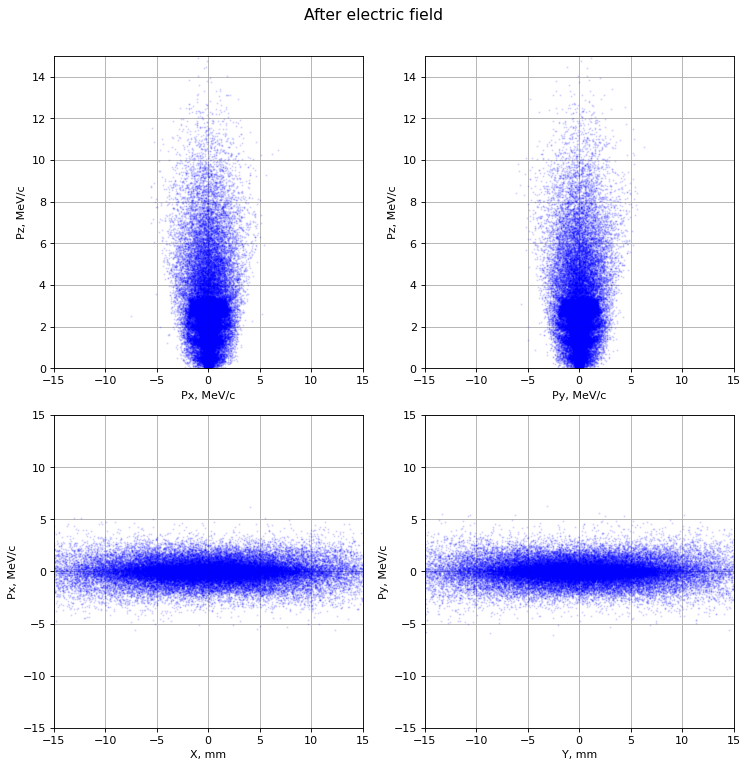

```python
from array import array
import numpy as np
import pylab as pl
import matplotlib.pyplot as plt
from matplotlib.pyplot import figure
import math

# Coordinates,mm and momenta,MeV for Z after target
with open('R_2m_el_wg/R_X_El.txt', 'r') as file:
    X = [float(x) for x in file.read().split(',')]
with open('R_2m_el_wg/R_Y_El.txt', 'r') as file:
    Y = [float(x) for x in file.read().split(',')]
with open('R_2m_el_wg/R_Px_El.txt', 'r') as file:
    Px = [float(x) for x in file.read().split(',')]
with open('R_2m_el_wg/R_Py_El.txt', 'r') as file:
    Py = [float(x) for x in file.read().split(',')]
with open('R_2m_el_wg/R_Pz_El.txt', 'r') as file:
    Pz = [float(x) for x in file.read().split(',')]

# X1 = [a / b for a, b in zip(Px, Pz)]
# Y1 = [a / b for a, b in zip(Py, Pz)]

figure(figsize=(10, 10), dpi=80)

plt.subplot(221)
plt.plot(Px, Pz, 'o', markersize=1, color='blue', alpha=0.1)
plt.ylabel('Pz, MeV/c')
plt.xlabel('Px, MeV/c')
plt.ylim(0,15)
plt.xlim(-15,15)
plt.grid(True)

plt.subplot(222)
plt.plot(Py, Pz, 'o', markersize=1, color='blue', alpha=0.1)
plt.ylabel('Pz, MeV/c')
plt.xlabel('Py, MeV/c')
plt.ylim(0,15)
plt.xlim(-15,15)
plt.grid(True)

plt.subplot(223)
plt.plot(X, Px, 'o', markersize=1, color='blue', alpha=0.1)
plt.ylabel('Px, MeV/c')
plt.xlabel('X, mm')
plt.ylim(-15,15)
plt.xlim(-15,15)
plt.grid(True)

plt.subplot(224)
plt.plot(Y, Py, 'o', markersize=1, color='blue', alpha=0.1)
plt.ylabel('Py, MeV/c')
plt.xlabel('Y, mm')
plt.ylim(-15,15)
plt.xlim(-15,15)
plt.grid(True)

plt.suptitle("After electric field", fontsize=14)

plt.subplots_adjust(top=0.92, bottom=0.08, left=0.10, right=0.95, hspace=0.15, wspace=0.2)

plt.show()
```

K = Bmax/Bmin = 5/0.5 = 10 V0, Vt0 in Bmin Particles with: Vt0^2/V0^2 >= 1/K - captured by the trap Vt0^2/V0^2 < 1/K - escaped the trap A = Vt0^2/V0^2

```
20172 27115
Overall positrons:  47287
The cone of loss:
e+ ecsaped the trap:  12121
e+ get captured:  35166
% of e+ get captured:  50.77609483517912
```

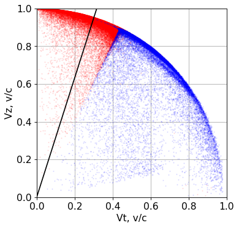

```python
from array import array
import numpy as np
import pylab as pl
import matplotlib.pyplot as plt
from matplotlib.pyplot import figure
import math

Bmin = 0.5 # Tesla
Bmax = 5 # Tesla
K = Bmax/Bmin

m0_c2 = 0.511  # Масса покоя позитрона в МэВ
c = 1

# Cone of loss
P_CL_es = 0
P_CL_nes = 0
P_CL_overall = 0
# Geant4 simulation
C = 0
P_G4_overall = 0
P_G4_nes = 0
P_G4_es = 0
Pz_es = np.array([])
Pp_es = np.array([])
Pz_nes = np.array([])
Pp_nes = np.array([])

Po_border = np.arange(0, 2)
Pt_border = np.sqrt(Po_border*Po_border/K)

# and momenta,MeV for Z after target
with open('R_2m_el_wg/R_Px_El.txt', 'r') as file:
    Px = [float(x) for x in file.read().split(',')]
with open('R_2m_el_wg/R_Py_El.txt', 'r') as file:
    Py = [float(x) for x in file.read().split(',')]
with open('R_2m_el_wg/R_Pz_El.txt', 'r') as file:
    Pz = [float(x) for x in file.read().split(',')]
with open('R_2m_el_wg/R_PID_El.txt', 'r') as file:
    ID_El = [float(x) for x in file.read().split(',')]
with open('R_2m_el_wg/R_PID_end.txt', 'r') as file:
    ID_end = [float(x) for x in file.read().split(',')]

Px = np.array(Px)
Py = np.array(Py)
Pp = np.sqrt(Px**2 + Py**2)
Pz = np.array(Pz)
ID_El = np.array(ID_El)
ID_end = np.array(ID_end)

# 1. Рассчитываем полную энергию E для каждой частицы
# E = sqrt( (p * c)^2 + (m0 * c^2)^2 )
total_impulse_squared = Pz**2 + Pp**2
E_total = np.sqrt(total_impulse_squared + m0_c2**2)

# 2. Рассчитываем скорости
# v = (p * c^2) / E
Vz = (Pz * c) / E_total
Vp = (Pp * c) / E_total

for x in ID_El:
    C = 1
    for y in ID_end:
        if x == y:
            Pz_es = np.append(Pz_es,Vz[P_G4_overall])
            Pp_es = np.append(Pp_es,Vp[P_G4_overall])
            P_G4_es = P_G4_es + 1
            C = 0
            break
    if C == 1:
        Pz_nes = np.append(Pz_nes,Vz[P_G4_overall])
        Pp_nes = np.append(Pp_nes,Vp[P_G4_overall])
        P_G4_nes = P_G4_nes + 1
    P_G4_overall = P_G4_overall + 1

#Po2 = [(a*a + b*b + c*c) for a, b, c in zip(Px, Py, Pz)]
#Ax = [a*a/b for a, b in zip(Px ,Po2)]
Ax = (Vp**2)/(Vz**2)
for x in Ax:
    if x < 1/K:
        P_CL_overall = P_CL_overall + 1
        P_CL_es = P_CL_es + 1
    else:
        P_CL_nes = P_CL_nes + 1
        P_CL_overall = P_CL_overall + 1
print(P_G4_nes, P_G4_es)
print("Overall positrons: ", P_CL_overall)
print("The cone of loss: ")
print("e+ ecsaped the trap: ", P_CL_es)
print("e+ get captured: ", P_CL_nes)
print("% of e+ get captured: ", P_CL_nes/69257*100)


figure(figsize=(5, 5), dpi=80)

plt.plot(Pp_es, Pz_es, 'o', markersize=1, color='red', alpha=0.1)
plt.plot(Pp_nes, Pz_nes, 'o', markersize=1, color='blue', alpha=0.1)
plt.plot(Pt_border, Po_border, -1*Pt_border, Po_border, markersize=1, color='black', alpha=1)
plt.ylabel('Vz, v/c',fontsize=14)
plt.xlabel('Vt, v/c',fontsize=14)
plt.ylim(0,1)
plt.xlim(0,1)
plt.xticks(fontsize=14)
plt.yticks(fontsize=14)
plt.grid(True)

plt.show()
```

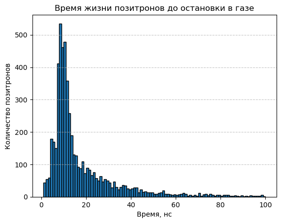

```python
from array import array
import numpy as np
import pylab as pl
import matplotlib.pyplot as plt
from matplotlib.pyplot import figure
import math

# Positron live time before stop
with open('R_2m_el_wg/R_Plt.txt', 'r') as file:
    Plt = [float(x) for x in file.read().split(',')]

bins=range(1, 101)

#figure(figsize=(5, 5), dpi=80)

plt.hist(Plt, bins, edgecolor='black')
plt.title("Время жизни позитронов до остановки в газе")
plt.xlabel('Время, нс')
plt.ylabel('Количество позитронов')
plt.grid(axis='y', linestyle='--', alpha=0.7)
plt.show()

plt.show()
```

```
905 66819
Overall positrons:  67724
The cone of loss:
e+ ecsaped the trap:  57775
e+ get captured:  9949
% of e+ get captured:  14.365334911994458
```

[figure not shown]

```python
from array import array
import numpy as np
import pylab as pl
import matplotlib.pyplot as plt
from matplotlib.pyplot import figure
import math

Bmin = 0.5 # Tesla
Bmax = 5 # Tesla
K = Bmax/Bmin

m0_c2 = 0.511  # Масса покоя позитрона в МэВ
c = 1

# Cone of loss
P_CL_es = 0
P_CL_nes = 0
P_CL_overall = 0
# Geant4 simulation
C = 0
P_G4_overall = 0
P_G4_nes = 0
P_G4_es = 0
Pz_es = np.array([])
Pp_es = np.array([])
Pz_nes = np.array([])
Pp_nes = np.array([])

Po_border = np.arange(0, 2)
Pt_border = np.sqrt(Po_border*Po_border/K)

# and momenta,MeV for Z after target
with open('R_2m_wel_wg/R_Px_El.txt', 'r') as file:
    Px = [float(x) for x in file.read().split(',')]
with open('R_2m_wel_wg/R_Py_El.txt', 'r') as file:
    Py = [float(x) for x in file.read().split(',')]
with open('R_2m_wel_wg/R_Pz_El.txt', 'r') as file:
    Pz = [float(x) for x in file.read().split(',')]
with open('R_2m_wel_wg/R_PID_El.txt', 'r') as file:
    ID_El = [float(x) for x in file.read().split(',')]
with open('R_2m_wel_wg/R_PID_end.txt', 'r') as file:
    ID_end = [float(x) for x in file.read().split(',')]

Px = np.array(Px)
Py = np.array(Py)
Pp = np.sqrt(Px**2 + Py**2)
Pz = np.array(Pz)
ID_El = np.array(ID_El)
ID_end = np.array(ID_end)

# 1. Рассчитываем полную энергию E для каждой частицы
# E = sqrt( (p * c)^2 + (m0 * c^2)^2 )
total_impulse_squared = Pz**2 + Pp**2
E_total = np.sqrt(total_impulse_squared + m0_c2**2)

# 2. Рассчитываем скорости
# v = (p * c^2) / E
Vz = (Pz * c) / E_total
Vp = (Pp * c) / E_total

for x in ID_El:
    C = 1
    for y in ID_end:
        if x == y:
            Pz_es = np.append(Pz_es,Vz[P_G4_overall])
            Pp_es = np.append(Pp_es,Vp[P_G4_overall])
            P_G4_es = P_G4_es + 1
            C = 0
            break
    if C == 1:
        Pz_nes = np.append(Pz_nes,Vz[P_G4_overall])
        Pp_nes = np.append(Pp_nes,Vp[P_G4_overall])
        P_G4_nes = P_G4_nes + 1
    P_G4_overall = P_G4_overall + 1

Po2 = [(a*a + b*b + c*c) for a, b, c in zip(Px, Py, Pz)]
Ax = [a*a/b for a, b in zip(Px ,Po2)]
for x in Ax:
    if x < 1/K:
        P_CL_overall = P_CL_overall + 1
        P_CL_es = P_CL_es + 1
    else:
        P_CL_nes = P_CL_nes + 1
        P_CL_overall = P_CL_overall + 1
print(P_G4_nes, P_G4_es)
print("Overall positrons: ", P_CL_overall)
print("The cone of loss: ")
print("e+ ecsaped the trap: ", P_CL_es)
print("e+ get captured: ", P_CL_nes)
print("% of e+ get captured: ", P_CL_nes/69257*100)


figure(figsize=(5, 5), dpi=80)

plt.plot(Pp_es, Pz_es, 'o', markersize=1, color='red', alpha=0.1)
plt.plot(Pp_nes, Pz_nes, 'o', markersize=1, color='blue', alpha=0.1)
plt.plot(Pt_border, Po_border, -1*Pt_border, Po_border, markersize=1, color='black', alpha=1)
plt.ylabel('Vz, v/c',fontsize=14)
plt.xlabel('Vt, v/c',fontsize=14)
plt.ylim(0,1)
plt.xlim(0,1)
plt.xticks(fontsize=14)
plt.yticks(fontsize=14)
plt.grid(True)

plt.show()
```

Some statistics without electric field Total Events: 5000000 Number of e+ born: 69290 Number of e- born: 1959848 Number of e+ escaped the trap: 67030 Number of e- escaped the trap: 1858326 Number of e+ reached the end of adiabatic device: 67948 Number of e- reached the end of adiabatic device: 1886978 Number of e+ reached the end of Electric field: 67948 Number of e- reached the end of Electric field: 1886975 e+ : 67948 - 67030 = 918 (1.32%) e- : 1886975 - 1858326 = 28649 (1.46%)

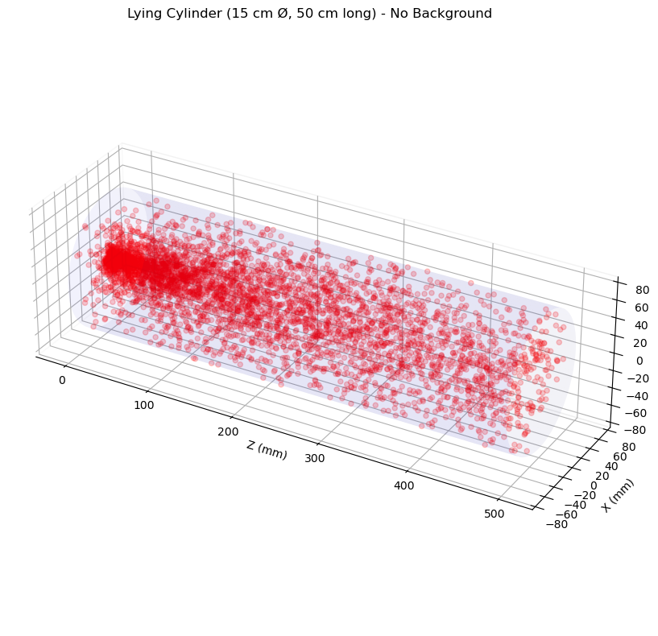

```python
import numpy as np
import matplotlib.pyplot as plt
from mpl_toolkits.mplot3d import Axes3D

# Cylinder parameters (in centimeters)
diameter = 150.0
radius = diameter / 2  # 7.5 cm
length = 500.0  # 0.5 m = 50 cm
resolution = 100

# Angular and axial coordinates (along x-axis for lying cylinder)
theta = np.linspace(0, 2 * np.pi, resolution)
x = np.linspace(0, length, resolution)
theta, x = np.meshgrid(theta, x)

# Y and Z: circular cross-section in YZ plane
y = radius * np.cos(theta)
z = radius * np.sin(theta)

# Coordinates for positrons stoped in gas
with open('R_2m_el_g/R_X_gas.txt', 'r') as file:
    Y = [float(x) for x in file.read().split(',')]
with open('R_2m_el_g/R_Y_gas.txt', 'r') as file:
    Z = [float(x) for x in file.read().split(',')]
with open('R_2m_el_g/R_Z_gas.txt', 'r') as file:
    X = [float(x) for x in file.read().split(',')]

X = [(a - 250) for a in X]

# Create figure with white background
fig = plt.figure(figsize=(10, 8))
fig.patch.set_facecolor('white')  # Background color of the figure
fig.patch.set_alpha(1)  # Fully opaque (or use 0 for transparency if saving as PNG)

ax = fig.add_subplot(111, projection='3d')

# Plot the surface with very low opacity
ax.plot_surface(x, y, z, color='blue', alpha=0.05, edgecolor='none')

# Plot the 100 points
ax.scatter(X, Y, Z, color='red', s=20, alpha=0.2, label='Points inside')

# --- Remove the grey background ---
ax.xaxis.pane.fill = False  # Remove x-plane pane
ax.yaxis.pane.fill = False  # Remove y-plane pane
ax.zaxis.pane.fill = False  # Remove z-plane pane

# --- Remove grid lines ---
ax.grid(True)

# --- Optional: Remove the ticks or make them black for visibility ---
ax.tick_params(color='black', labelcolor='black')
# If you want to hide axes completely, use:
# ax.axis('off')  # But this hides labels too

# Labels
ax.set_xlabel('Z (mm)', color='black')
ax.set_ylabel('X (mm)', color='black')
ax.set_zlabel('Y (mm)', color='black')
ax.set_title('Lying Cylinder (15 cm Ø, 50 cm long) - No Background', color='black')

# Set aspect ratio (optional, for better shape)
ax.set_box_aspect([length, diameter, diameter])

# Optional: view angle
# ax.view_init(elev=20, azim=45)

# Ensure the axes limits are visible
plt.tight_layout()

# Show the plot
plt.show()
```

Some statistics: Number of electrons fallen on the target: 4000000 Energy of the electrons: 20 MeV Number of e+ born: 55272 (1.38%) Number of e+ captured in gas: 4457 (0.111%) Now we have the new configuration

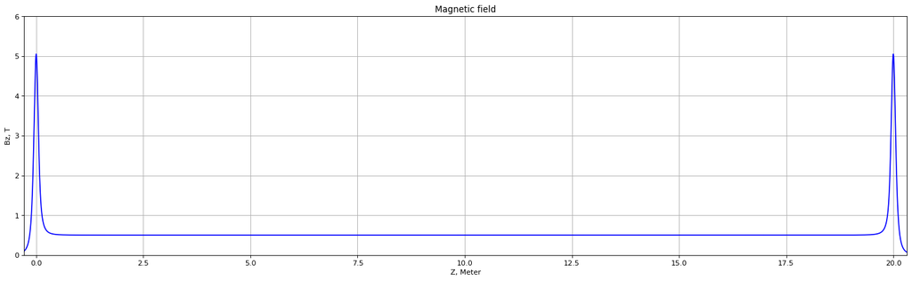

```python
from array import array
import numpy as np
import pylab as pl
import matplotlib.pyplot as plt
from matplotlib.pyplot import figure
import math

# Constant
mu0 = math.pi
# Solenoids on the ends
B0 = 5 # Tesla
L = 0.06 # Meter
R = 0.075 # Meter
NI = B0*L/mu0/(L/2/math.sqrt((L/2)*(L/2)+R*R))
# Solenoid in the mid
B0m = 0.5 # Tesla
Lm = 19.8 # Meter
Rm = 0.075 # Meter
NIm = B0m*Lm/mu0/(Lm/2/math.sqrt((Lm/2)*(Lm/2)+Rm*Rm))

z = array('d',[])
Bz = array('d',[])

for x in np.arange(-0.5, 20.5, 0.001):
    z.append(x)
    Bl = mu0*NI/(2*L)*((x+L/2)/math.sqrt((x+L/2)*(x+L/2)+R*R)-((x-L/2)/math.sqrt((x-L/2)*(x-L/2)+R*R)))
    Br = mu0*NI/(2*L)*((x-20+L/2)/math.sqrt((x-20+L/2)*(x-20+L/2)+R*R)-((x-20-L/2)/math.sqrt((x-20-L/2)*(x-20-L/2)+R*R)))
    Bm = mu0*NIm/(2*Lm)*((x-10+Lm/2)/math.sqrt((x-10+Lm/2)*(x-10+Lm/2)+Rm*Rm)-((x-10-Lm/2)/math.sqrt((x-10-Lm/2)*(x-10-Lm/2)+Rm*Rm)))
    Bz.append(Bl+Br+Bm)

figure(figsize=(22, 6), dpi=80)
plt.plot(z, Bz, "b")
plt.title('Magnetic field')
plt.ylabel('Bz, T')
plt.xlabel('Z, Meter')
plt.grid(True)
plt.axis([-0.28, 20.32, 0, 6])
plt.show()
```

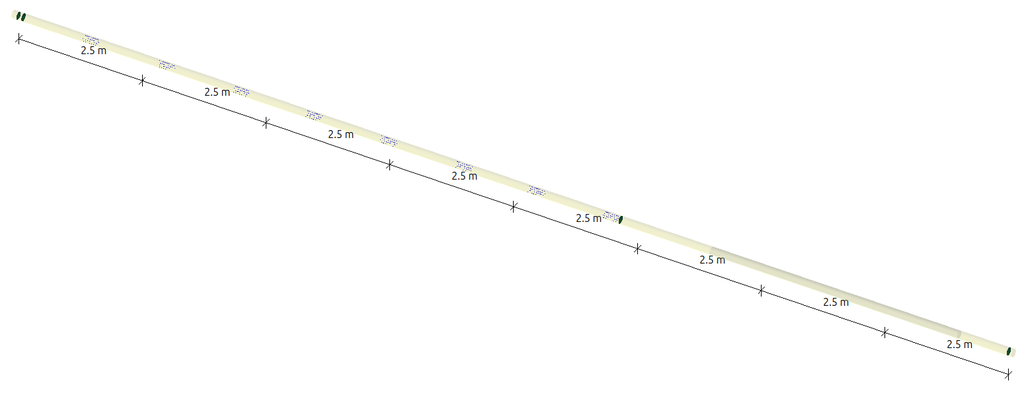